# Detection of Chagas Disease from the ECG: PhysioNet Challenge 2025

### Chagas Disease Overview

- **Cause & Transmission**: Caused by *Trypanosoma cruzi*, primarily spread by **triatomine insects**, but also through **blood transfusions, organ transplants, and congenital transmission**.
- **Disease Progression**: Two phases—**acute (mild/nonspecific symptoms)** and **chronic (asymptomatic in most, but 30-40% develop severe complications, mainly cardiac)**. **Early antiparasitic treatment is effective**, but loses efficacy as the infection progresses.
- **Historical Background**: **Named after Carlos Chagas**, who discovered it in 1909. Chronic complications, especially **cardiac and digestive issues**, typically appear **10 to 30 years** post-infection.
- **Diagnosis**: Detected via **blood tests (parasite detection or serological tests for antibodies)**.
- **Cardiac Impact & ECG Role**: **Chagas cardiomyopathy** can cause **heart damage, arrhythmias, conduction disorders, and dilated cardiomyopathy**. **Severe cases may lead to sudden cardiac death**, though the **indeterminate chronic form lacks ECG abnormalities**, making early detection challenging.

### About the Challenge

- The **George B. Moody PhysioNet Challenge 2025** [[1]](https://moody-challenge.physionet.org/2025/) is a **prestigious annual competition** focused on advancing **physiological and clinical problem-solving**.
- This year’s challenge targets **Chagas disease**, a **serious cardiovascular threat** prevalent in **Central and South America**.
- Participants must develop **open-source algorithms** to **detect Chagas disease** using **standard 12-lead ECGs**.
- The goal is to **improve screening efficiency**, identifying **potential cases for confirmatory serological testing** while optimizing healthcare resources.
- Inspired by this, our objective is to build a model that can **accurately detect Chagas disease using only a short (~10-second) 12-lead ECG recording**.

### Dataset

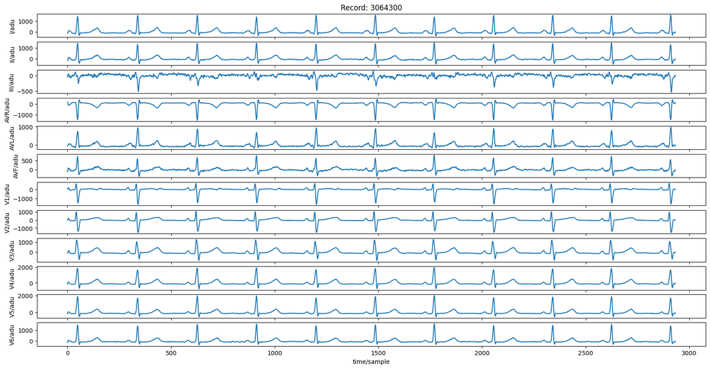

```python
wfdb.plot_wfdb(record=wfdb.rdrecord(record, physical=False), figsize=(20, 10), time_units='samples')
```

### ECG features

[figure not shown]

### Feature Extraction & Data Processing

- **ECG Feature Extraction**: Relevant features are derived from **fiducial points (P, Q, R, S, T waves)** and **segment durations**, enabling numerical representation of the ECG signal for **machine learning classification**.
- **Chagas Disease Detection**: Research indicates that **ECG pattern durations** are strongly associated with Chagas disease, making them **key diagnostic features**.
- **Implementation**: Feature extraction is handled in **`preprocessing.py`** using [**NeuroKit2**](https://neuropsychology.github.io/NeuroKit/) ensuring correct wave order. The extracted features are then merged with the metadata (age, gender, Chagas label) and aggregated in a single csv file.
- **Dataset Challenges & Solutions**: The dataset is **large and imbalanced**, making full processing computationally expensive. To mitigate this:
  - A **partitioned subset** of the data is used for efficient experimentation.
  - **Downsampling** is applied to **balance seropositive and seronegative cases**, ensuring unbiased model training.

# Exploratory Data Analysis

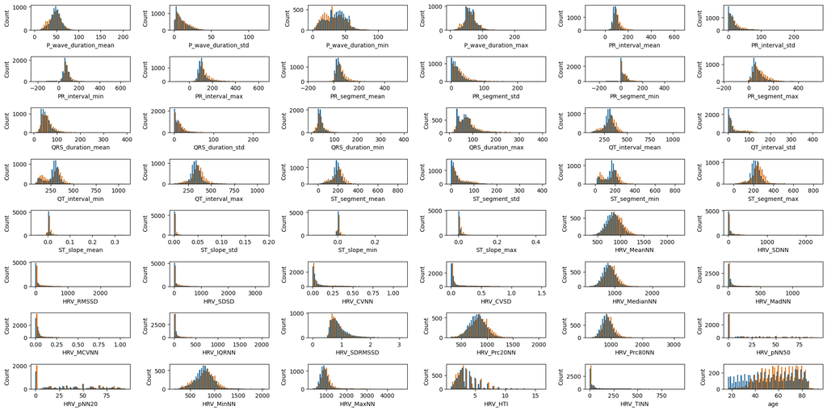

```python
_, axes = plt.subplots(nrows=8, ncols=6, figsize=(20, 10))
for ax, cname in zip(axes.ravel(), num_cols):
    sn.histplot(data=df, x=cname, bins=50, stat="count", alpha=1, kde=False, multiple='dodge', ax=ax, hue='chagas', legend=False)
plt.tight_layout()
plt.show()
```

```python
t_test_df.sort_values(by='p_value')
```

|  | column | t_stat | p_value | is_significant |
| --- | --- | --- | --- | --- |
| 6 | PR_segment_mean | 20.819895 | 1.633643e-94 | True |
| 7 | PR_segment_max | 20.634896 | 4.930207e-93 | True |
| 5 | PR_interval_max | 18.113069 | 2.226532e-72 | True |
| 21 | HRV_MaxNN | 15.886669 | 2.847833e-56 | True |
| 3 | PR_interval_mean | 15.732206 | 3.498921e-55 | True |
| 0 | P_wave_duration_mean | -15.235253 | 5.901368e-52 | True |
| 15 | ST_segment_max | 14.821371 | 2.896867e-49 | True |
| 17 | HRV_SDRMSSD | -14.733790 | 9.797298e-49 | True |
| 19 | HRV_Prc80NN | 13.986132 | 4.023160e-44 | True |
| 1 | P_wave_duration_min | -13.572657 | 1.116486e-41 | True |
| 13 | QT_interval_max | 12.460313 | 2.006407e-35 | True |
| 22 | HRV_HTI | -11.860685 | 2.772502e-32 | True |
| 16 | HRV_MedianNN | 10.322695 | 6.949631e-25 | True |
| 10 | QRS_duration_max | 9.578422 | 1.166052e-21 | True |
| 8 | QRS_duration_mean | 9.532662 | 1.821155e-21 | True |
| 2 | P_wave_duration_max | -8.089928 | 6.502718e-16 | True |
| 18 | HRV_Prc20NN | 6.024534 | 1.742408e-09 | True |
| 4 | PR_interval_min | 5.904194 | 3.640283e-09 | True |
| 14 | ST_segment_mean | 5.721862 | 1.079176e-08 | True |
| 12 | QT_interval_min | -4.514126 | 6.416034e-06 | True |
| 11 | QT_interval_mean | 3.694889 | 2.209494e-04 | True |
| 9 | QRS_duration_min | 3.558609 | 3.743054e-04 | True |
| 20 | HRV_MinNN | 2.215779 | 2.672431e-02 | True |

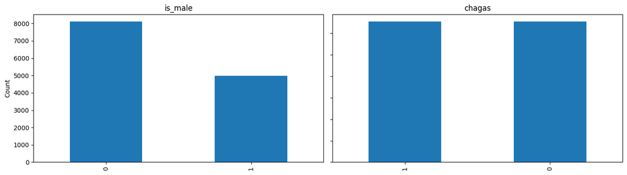

```python
_, axes = plt.subplots(nrows=1, ncols=2)
for i, cname in enumerate(cat_cols + ['chagas']):
    df[cname].value_counts().plot(kind='bar', ax=axes[i], figsize=figsize, title=cname, ylabel='Count', xlabel='', sharey=True)

plt.tight_layout()
```

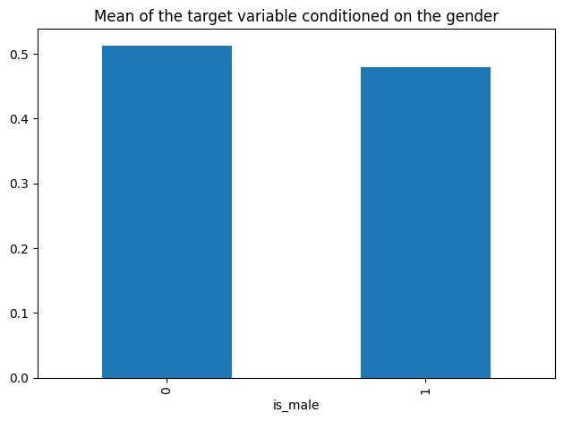

```python
df.groupby('is_male')['chagas'].mean().plot.bar(title='Mean of the target variable conditioned on the gender')
plt.tight_layout()
```

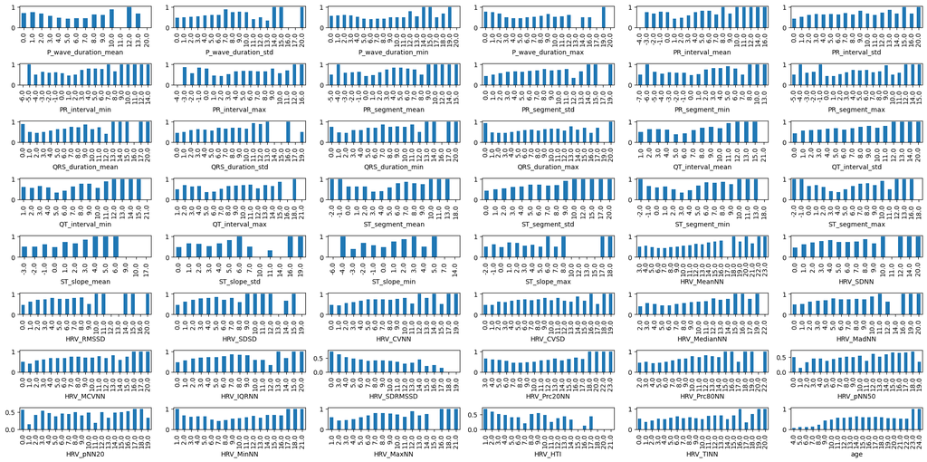

```python
_, axes = plt.subplots(nrows=8, ncols=6, figsize=(20,10))
for ax, cname in zip(axes.ravel(), num_cols):
    bin_size = (df[cname].max() - df[cname].min()) / 20
    df['chagas'].groupby(df[cname] // bin_size).mean().plot.bar(ax=ax)
plt.tight_layout()
```

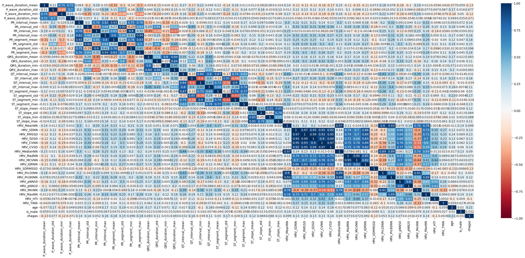

```python
plt.figure(figsize=(27,12))
sn.heatmap(df.corr(method='pearson'), annot=True, vmin=-1, vmax=1, cmap='RdBu')
plt.tight_layout()
```

## A more in-depth analysis of the data

From the literature we see that:

- Strong Link Between Chagas Disease & Abnormal ECG [3]90529-x)
  - Seropositive individuals are 4.3x more likely to show abnormal ECG patterns than seronegative ones.
  - Higher prevalence observed in men.
- Age-Dependent Increase in ECG Abnormalities [3]90529-x)
  - **10-14**, ECG abnormalities are similar between the two groups.
  - **25-44**, abnormal ECG occurrence is 9.3x higher in seropositive individuals.
  - **44-64**, the ratio decreases.
  - **64+**, roughly equal proportion between the groups.

How can we recognise an abnormal ecg?

### Ventricular Rate

**Claim**:

- Seropositive persons presents **significantly lower ventricular rates** [[4]](https://doi.org/10.4269/ajtmh.2007.77.495).

**Ventricular Rate:** The ventricular rate represents the number of ventricular contractions per minute (beats per minute, BPM) and indicates the heart's electrical pacing.

- A known cause of low Ventricular Rate is the presence of RBBB, that is know to be a symptom of the chagas disease [[4]](https://doi.org/10.4269/ajtmh.2007.77.495)

**HRV_MeanNN:** MeanNN is the average NN interval (time between normal heartbeats) and is inversely related to ventricular rate.

- Higher MeanNN values indicate a lower ventricular rate

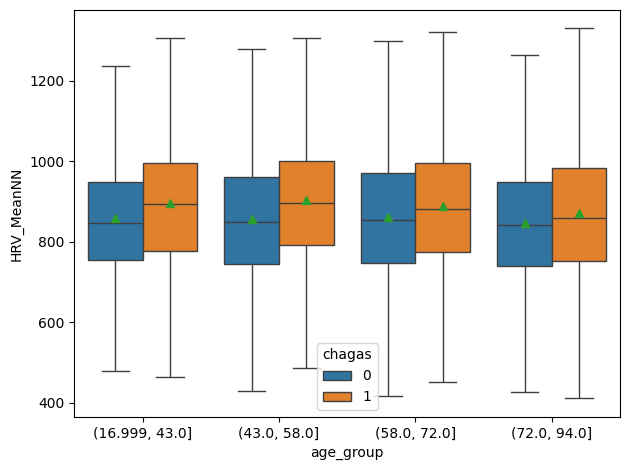

```python
df['age_group'] = pd.qcut(df['age'], q=4)
sn.boxplot(x='age_group', y='HRV_MeanNN', hue='chagas', data=df, showfliers=False, showmeans=True)
plt.tight_layout()
plt.show()
```

### Heart rate variability (HRV_HTI)

**Claim:**

- Arrhytmias occur 2 times more frequently in seropositive than among seronegative invidivuals [3]90529-x).

**HRV_HTI**: Measures heart rate regularity, calculated as the total number of RR intervals divided by the height of the RR interval histogram.

- Higher HRV_HTI values indicate more regular RR intervals, while lower values suggest increased irregularity.

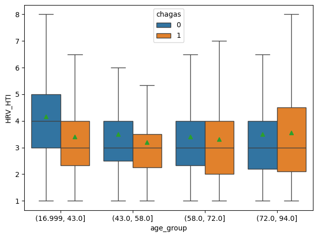

```python
sn.boxplot(x='age_group', y='HRV_HTI', hue='chagas', data=df, showfliers=False, showmeans=True)
plt.tight_layout()
plt.show()
```

### ST-T wave abnormalities (ST_slope)

**Claim:**

- Chagas cardiomyopathy presents nonspecific ST- and T-wave abnormalities [[7]](https://doi.org/10.1016/j.lana.2024.100832).
- Common abnormalities are right bundle branch block (RBBB), left anterior fascicular block, and diffuse ST-T changes.

**ST_slope:** Measures the slope between the S and T wave.

- In RBBB, this manifests as ST depression and/or T-wave inversion.

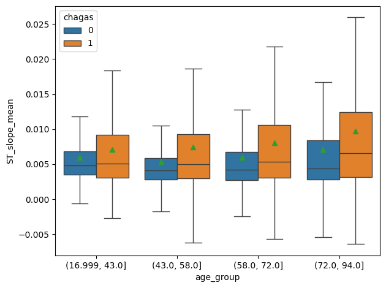

```python
sn.boxplot(x='age_group', y='ST_slope_mean', hue='chagas', data=df, showfliers=False, showmeans=True)
plt.tight_layout()
plt.show()
```

### QRS Duration

**Claim:**

- Seropositive people had substantially longer QRS intervals than seronegative persons [3]90529-x) [[4]](https://doi.org/10.4269/ajtmh.2007.77.495).
- 83.5% of individuals with QRS intervals above 0.09s were seropositive, while only 4.4% of seronegative individuals had QRS intervals above this threshold. [3]90529-x)

**QRS Duration:** is the time between the start of the Q wave and the end of the S wave, representing how long it takes for the ventricles to fully depolarize.

- Prolonged QRS duration may indicate conduction abnormalities linked to Chagas disease.

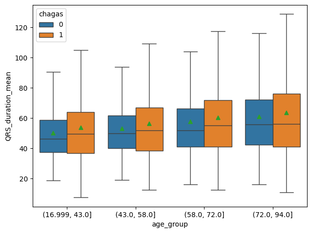

```python
sn.boxplot(x='age_group', y='QRS_duration_mean', hue='chagas', data=df, showfliers=False, showmeans=True)
plt.tight_layout()
plt.show()
```

### Standardization of the data

The StandardScaler is applied to the numerical columns to have a better distribution of the data by subtracting the mean and dividing by the standard deviation.

We first dropped the `age_group` column since it was not used inside our models and then applied the StandardScaler to the numerical columns.

The splitting between training and testing sets is done by stratifying the target variable and shuffling the data. For the test set, we used 20% of the data.

```python
X, y = df.drop(columns=['chagas', 'age_group'], axis=1), df['chagas']

X_train, X_test, y_train, y_test = train_test_split(X, y, test_size=0.2, random_state=SEED, stratify=y, shuffle=True)
scaler = StandardScaler()
X_train.iloc[:, :-1] = scaler.fit_transform(X_train.iloc[:, :-1])
X_test.iloc[:, :-1] = scaler.transform(X_test.iloc[:, :-1])
```

```python
results_dict = {}

def print_results(model, y_test, y_pred, y_pred_proba):
    acc = accuracy_score(y_test, y_pred)
    auc = roc_auc_score(y_test, y_pred_proba)
    f1 = f1_score(y_test, y_pred)
    f_beta = fbeta_score(y_test, y_pred, beta=0.5)
    print(f'Accuracy: {acc:.4f}')
    print(f'ROC-AUC: {auc:.4f}')
    print(f'F1-score: {f1:.4f}')
    print("F-beta score", f_beta)
    cm = confusion_matrix(y_test, y_pred, labels=[0, 1], normalize="all")
    disp = ConfusionMatrixDisplay(confusion_matrix=cm,
                              display_labels=['Seronegative', 'Seropositive'])
    disp.plot()
    plt.show()

    return {'acc': acc, 'auc': auc, 'f1': f1, 'f_beta': f_beta}
```

# Logistic Regression

## Key Features

- **L1 Regularization:** Promotes sparsity, identifies less useful features.
- **Solver:** SAGA chosen for efficiency with L1 and scalability for large datasets.

$$\text{argmin}_{\theta}\ H\biggl(y, f(x,\theta)\biggr) + \frac{1}{C} ||\theta||_1$$

## Hyperparameter Tuning

- **Parameter C:** Controls regularization strength.
- **GridSearchCV:** Tuned C with ROC-AUC as performance metric.

## Insights on Tuning C

- **Bias-Variance Tradeoff:**
  - Small C → Strong regularization → Risk of underfitting.
  - Large C → Weak regularization → Risk of overfitting.
- **Data-Driven Results:** Optimal C balances generalization and training performance.
- **Benefits of L1:** Sparsity, feature selection, improved interpretability.

```python
lr_score_cv, lr_score_test = gscv.best_score_, roc_auc_score(y_test, lr.predict_proba(X_test)[:, 1])
print(f'AUC score for C={lr_params["C"]:.2f}: {lr_score_cv:.2f} (cross-validation), {lr_score_test:.2f} (test)')
```

```
AUC score for C=10.00: 0.75 (cross-validation), 0.75 (test)
```

```
Accuracy: 0.6828
ROC-AUC: 0.7457
F1-score: 0.6722
F-beta score 0.6861796484437994
```

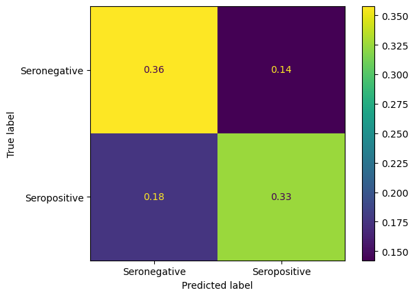

```python
results_dict['Logistic Regression'] = print_results(lr, y_test, lr.predict(X_test), lr.predict_proba(X_test)[:, 1])
```

```python
pd.DataFrame({'variable': X.columns, 'coeff': np.abs(lr.coef_[0]), 'sign': ['neg' if lr.coef_[0][i] < 0 else 'pos' for i in range(len(X.columns))]}).sort_values(by='coeff', ascending=False).head(20)
```

|  | variable | coeff | sign |
| --- | --- | --- | --- |
| 32 | HRV_CVNN | 0.750192 | pos |
| 21 | ST_segment_std | 0.749812 | pos |
| 44 | HRV_MaxNN | 0.628669 | neg |
| 1 | P_wave_duration_std | 0.615769 | pos |
| 22 | ST_segment_min | 0.547871 | pos |
| 3 | P_wave_duration_max | 0.530417 | neg |
| 2 | P_wave_duration_min | 0.487001 | pos |
| 39 | HRV_Prc20NN | 0.469673 | pos |
| 12 | QRS_duration_mean | 0.452798 | pos |
| 20 | ST_segment_mean | 0.391311 | pos |
| 33 | HRV_CVSD | 0.375549 | pos |
| 29 | HRV_SDNN | 0.357011 | pos |
| 16 | QT_interval_mean | 0.349609 | neg |
| 42 | HRV_pNN20 | 0.344252 | neg |
| 48 | is_male | 0.335431 | neg |
| 11 | PR_segment_max | 0.311716 | neg |
| 24 | ST_slope_mean | 0.307068 | pos |
| 31 | HRV_SDSD | 0.277912 | neg |
| 43 | HRV_MinNN | 0.269241 | pos |
| 9 | PR_segment_std | 0.264337 | pos |

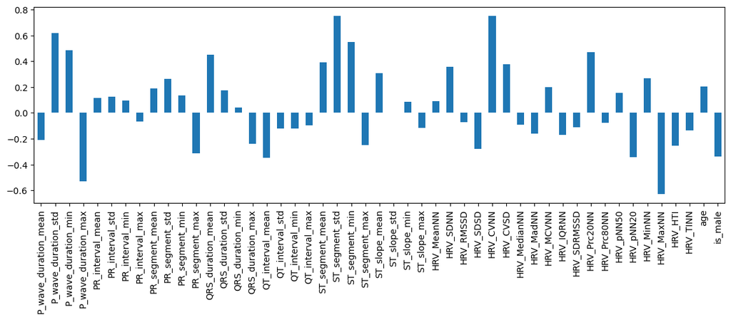

```python
lr_coefs = pd.Series(index=X.columns, data=lr.coef_[0])
lr_coefs.plot(kind='bar', figsize=figsize)
plt.show()
```

# XGBoost

## Key Features

- **Algorithm:** XGBoost with hist tree method for computational efficiency on large datasets.
- **Feature Importance:**
  - **Total Gain Importance:** Considers both frequency and magnitude of feature contributions across splits.

## Benefits

- **Performance:** Efficient and effective for large datasets.
- **Explainability:** Enhances interpretability for AI through detailed feature contribution analysis.

```python
base_est = xgboost.XGBClassifier(tree_method='hist', importance_type='total_gain', n_jobs=-1)
param_grid={'max_depth': [2, 3, 4], 'n_estimators': list(range(20, 41, 5)), 'reg_lambda': np.linspace(0, 500, 6)}
gscv = GridSearchCV(base_est, param_grid=param_grid, n_jobs=-1)
gscv.fit(X_train, y_train)
xbm, xbm_params = gscv.best_estimator_, gscv.best_params_
```

```python
xbm_score_test = roc_auc_score(y_test, xbm.predict_proba(X_test)[:, 1])
print(f'AUC score for max_depth={xbm_params["max_depth"]}, n_estimators={xbm_params["n_estimators"]}, reg_lambda={xbm_params["reg_lambda"]:.2f}: {xbm_score_test:.2f} (test)')
```

```
AUC score for max_depth=4, n_estimators=40, reg_lambda=100.00: 0.78 (test)
```

```
Accuracy: 0.7050
ROC-AUC: 0.7813
F1-score: 0.7145
F-beta score 0.7011177239076789
```

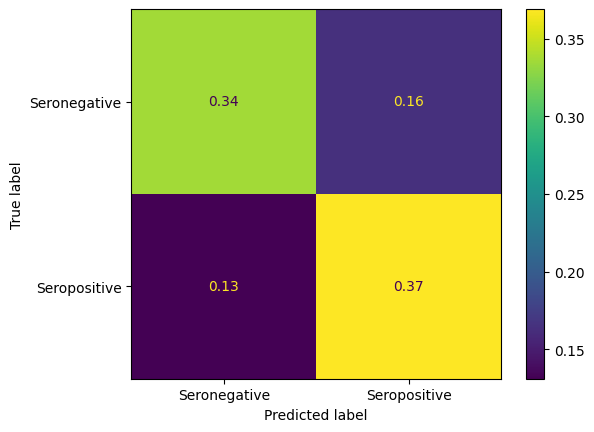

```python
results_dict['XGBoost'] = print_results(xbm, y_test, y_pred=xbm.predict(X_test), y_pred_proba=xbm.predict_proba(X_test)[:, 1])
```

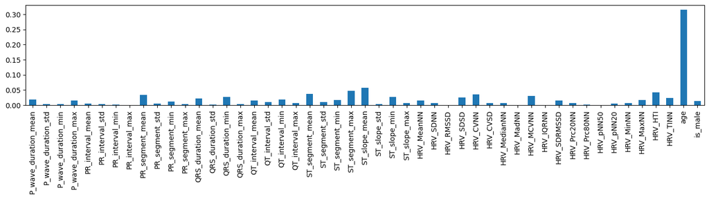

```python
xbm_imp = pd.Series(index=X.columns, data=xbm.feature_importances_)
xbm_imp.plot(kind='bar', figsize=figsize)
plt.tight_layout()
plt.show()
```

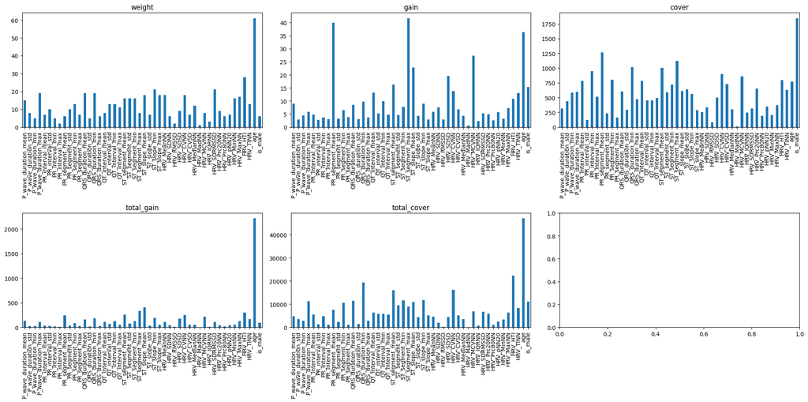

```python
_, axes = plt.subplots(nrows=2, ncols=3, figsize=(20, 10))
for ax, imp_type in zip(axes.ravel(), ['weight', 'gain', 'cover', 'total_gain', 'total_cover']):
    pd.Series(xbm.get_booster().get_score(importance_type=imp_type)).plot.bar(ax=ax, title=imp_type)
plt.tight_layout()
```

# Permutation Importance

## Key Insights

- **Data Dependence:** Feature importance varies with the dataset.
  - Misconception: Important features are universally best regardless of the dataset.

## Methodology

- **Definition:** Model-agnostic approach.
  - Randomly shuffle feature values.
  - Measure impact on model performance.
- **Purpose:** Assess feature importance independently of internal model metrics.

## Application

- **Datasets:** Computed on training and testing sets to check consistency.
- **Model:** Used XGBoost due to its superior performance.

## Benefits

- **Robust Evaluation:** Validates feature importance across models and datasets.
- **Model Independence:** Avoids reliance on specific model-based metrics.

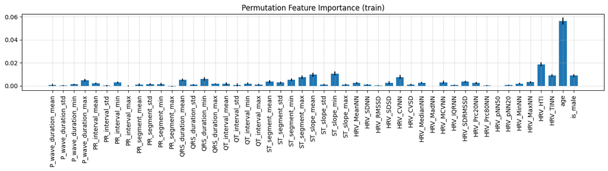

```python
util.plot_bars(xbm_p_imp, figsize=figsize, std=r_train.importances_std, title='Permutation Feature Importance (train)', rotation=90)
```

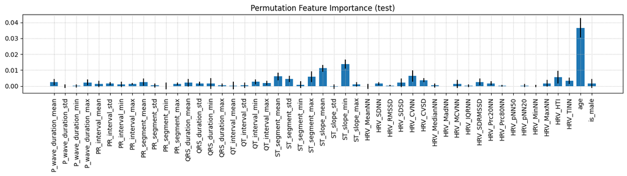

```python
util.plot_bars(xbm_p_imp, figsize=figsize, std=r_test.importances_std, title='Permutation Feature Importance (test)', rotation=90)
```

# SHAP Values

## Key Features

- **Purpose:** Explain predictions of the XGBoost model with high accuracy.
- **Origin:** Based on Shapley values from game theory.
  - Assigns importance to features by analyzing their marginal contributions across all feature combinations.

## Methodology

- **Explainer Definition:** Created using a sample of 100 training points.
- **Computation:** SHAP values calculated for the test set.
  - Larger samples improve accuracy but increase computational time (~1 hour for XGBoost).

## Comparison

- **Versus Permutation Importance:**
  - SHAP is more accurate.
  - Provides detailed insights into individual prediction contributions.

## Benefits

- **Explainability:** Highlights the contribution of each feature to model predictions.
- **Robustness:** Suitable for high-performing models like XGBoost.

```python
f = lambda x: xbm.predict_proba(x)[:,1]
explainer = shap.KernelExplainer(f, shap.sample(X_train, 100), link='logit', seed=SEED)
```

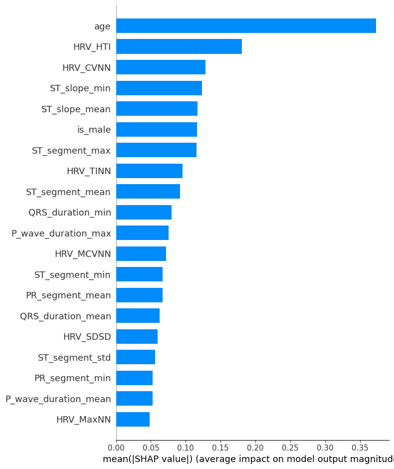

```python
shap.summary_plot(shap_values, X_test, plot_type='bar', max_display=20)
```

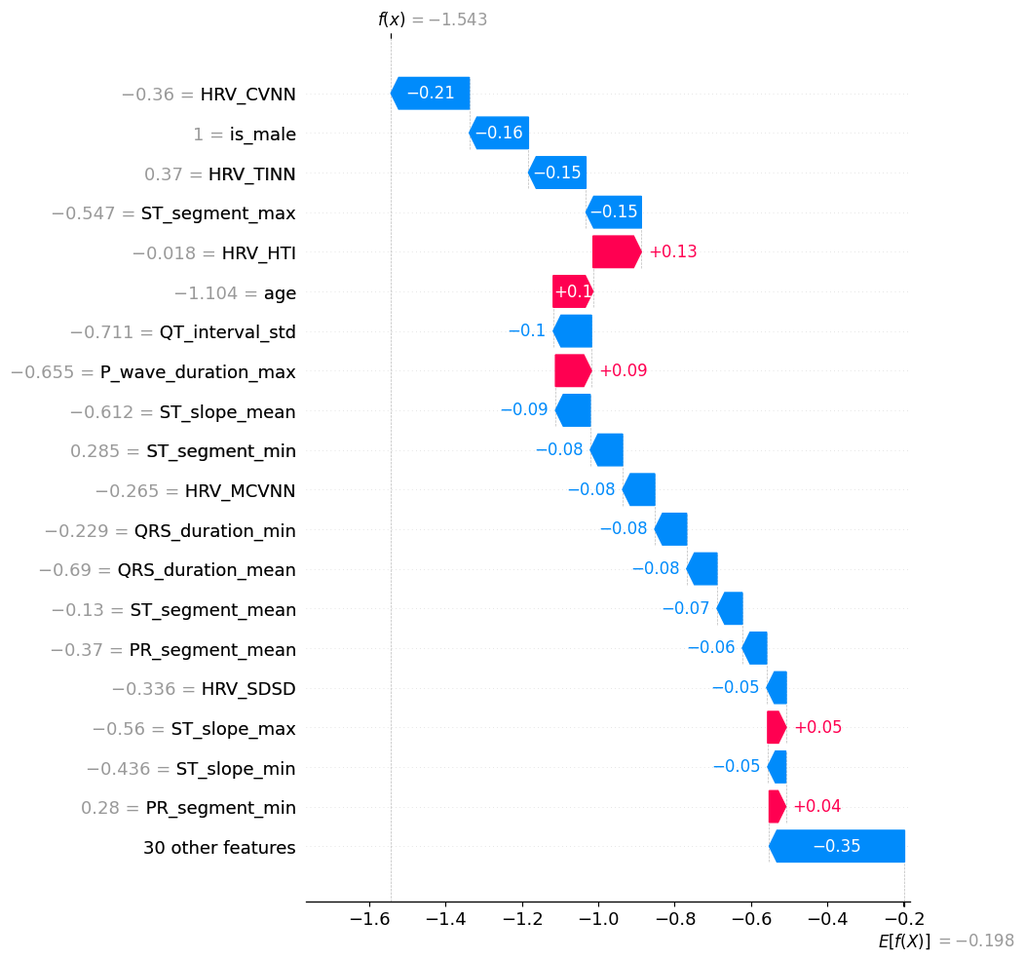

```python
shap.waterfall_plot(shap.Explanation(values=shap_values[0], base_values=explainer.expected_value, data=X_test.iloc[0], feature_names=X.columns.tolist()), max_display=20)
```

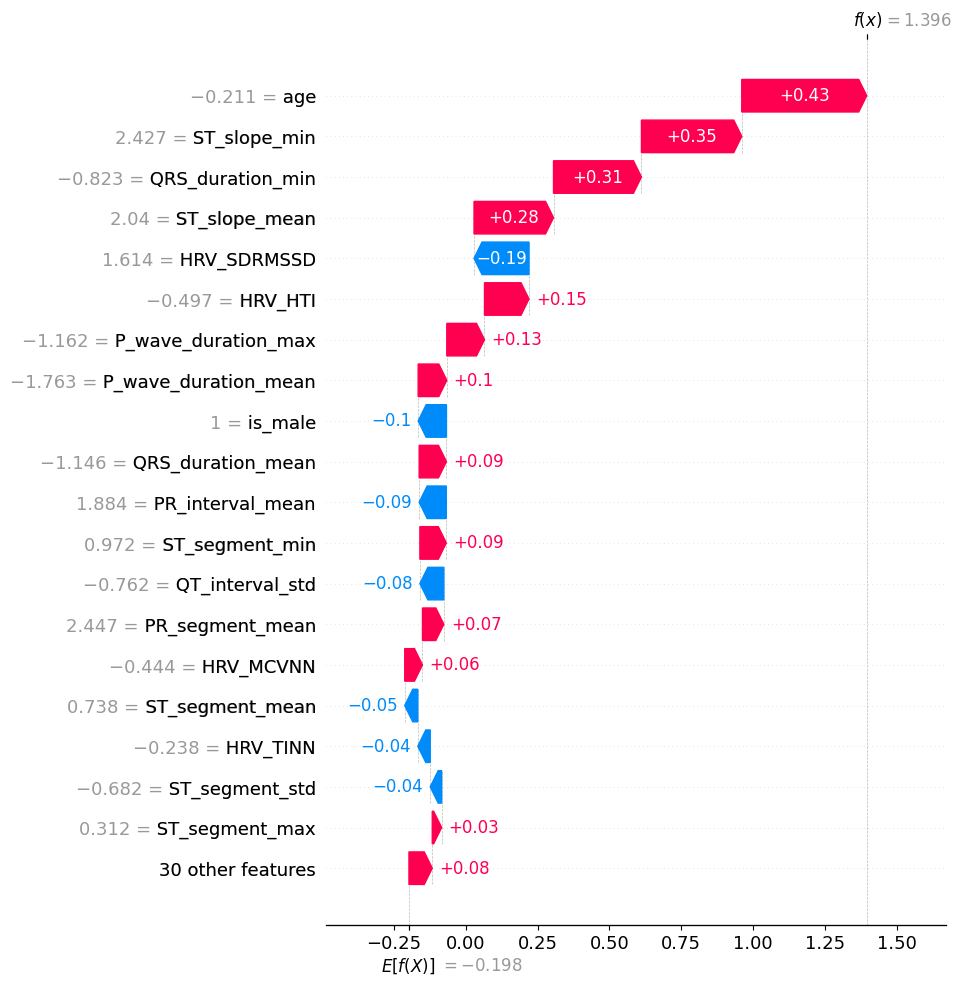

```python
shap.waterfall_plot(shap.Explanation(values=shap_values[1], base_values=explainer.expected_value, data=X_test.iloc[1], feature_names=X.columns.tolist()), max_display=20)
```

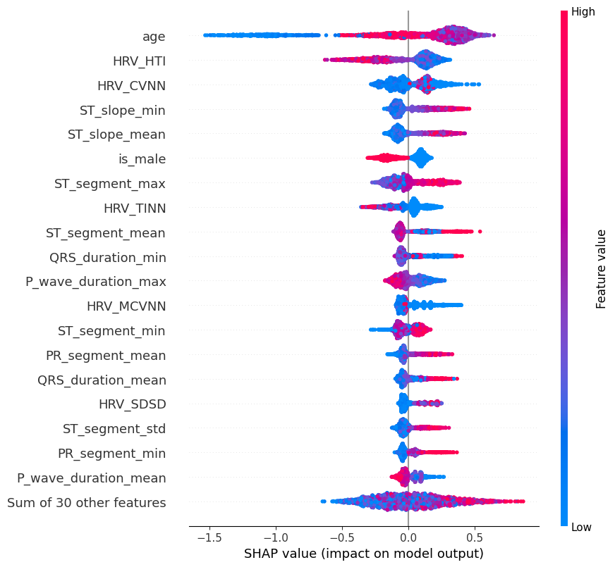

```python
shap.plots.beeswarm(shap_values, max_display=20)
```

# Feature selection

```python
shap_mean = np.abs(shap_values.values).mean(axis=0)
shap_mean = pd.Series(index=X.columns, data=shap_mean)
shap_mean.sort_values(ascending=False, inplace=True)
best_20_shap = shap_mean.head(20)
```

```python
X_train_fs = X_train[best_20_shap.index]
X_test_fs = X_test[best_20_shap.index]

base_est = xgboost.XGBClassifier(tree_method='hist', importance_type='total_gain')
param_grid={'max_depth': [2, 3, 4], 'n_estimators': list(range(20, 41, 5)), 'reg_lambda': np.linspace(0, 500, 6)}
gscv_fs = GridSearchCV(base_est, param_grid=param_grid, n_jobs=-1)
gscv_fs.fit(X_train_fs, y_train)
xbm_fs, xbm_params_fs = gscv_fs.best_estimator_, gscv_fs.best_params_
y_pred = xbm_fs.predict_proba(X_test_fs)[:, 1]
xbm_score_test_fs = roc_auc_score(y_test, y_pred)

print(f'AUC score for max_depth={xbm_params_fs["max_depth"]}, n_estimators={xbm_params_fs["n_estimators"]}, reg_lambda={xbm_params_fs["reg_lambda"]:.2f}: {xbm_score_test_fs:.4f} (test)')
```

```
AUC score for max_depth=4, n_estimators=40, reg_lambda=100.00: 0.7804 (test)
```

```
Accuracy: 0.7023
ROC-AUC: 0.7804
F1-score: 0.7103
F-beta score 0.6992238980817104
```

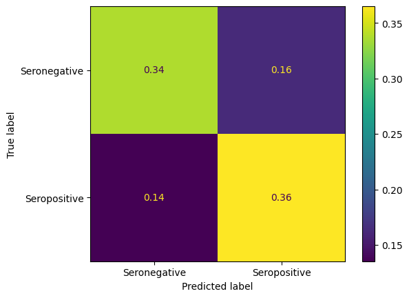

```python
results_dict['XGBoost-SHAP'] = print_results(xbm_fs, y_test, xbm_fs.predict(X_test_fs), xbm_fs.predict_proba(X_test_fs)[:, 1])
```

## BorutaPy

- **Generate and Evaluate**
  1. **extend** the dataset by adding and shuffling copies of all variables
  2. **run** a random forest to compute Z-scores for all features
- **Compare Scores**
  1. **finds** maximum Z-score among shadow attributes (MZSA)
  2. **assign** a “hit” to attributes that exceeds this value
- **Statistical Testing & Iteration**
  1. For undetermined attributes, perform a **two-sided test** against the MZSA to label them as important or unimportant
  2. **remove** shadow attributes
  3. **repeat** until all attributes are classified or limit is reached

```python
bfs = BorutaPy(xbm, n_estimators='auto', max_iter=100, verbose=0, random_state=SEED, early_stopping=True)
bfs.fit(X=X, y=y)
```

```
BorutaPy(early_stopping=True,
         estimator=XGBClassifier(base_score=None, booster=None, callbacks=None,
                                 colsample_bylevel=None, colsample_bynode=None,
                                 colsample_bytree=None, device=None,
                                 early_stopping_rounds=None,
                                 enable_categorical=False, eval_metric=None,
                                 feature_types=None, gamma=None,
                                 grow_policy=None, importance_type='total_gain',
                                 interaction_constraints=None,
                                 learning_rate=None, max_bin=None,
                                 max_cat_threshold=None, max_cat_to_onehot=None,
                                 max_delta_step=None, max_depth=4,
                                 max_leaves=None, min_child_weight=None,
                                 missing=nan, monotone_constraints=None,
                                 multi_strategy=None, n_estimators=173,
                                 n_jobs=-1, num_parallel_tree=None,
                                 random_state=381215112, ...),
         n_estimators='auto',
         random_state=RandomState(MT19937) at 0x7682C5A9F340)
```

```python
pd.DataFrame(data=bfs.ranking_, index=X.columns).rename(columns={0: 'Ranking'}).sort_values(by='Ranking', ascending=True)
```

|  | Ranking |
| --- | --- |
| P_wave_duration_mean | 1 |
| ST_segment_mean | 1 |
| ST_segment_std | 1 |
| ST_segment_min | 1 |
| ST_segment_max | 1 |
| age | 1 |
| ST_slope_min | 1 |
| HRV_MeanNN | 1 |
| HRV_SDSD | 1 |
| HRV_CVNN | 1 |
| HRV_CVSD | 1 |
| HRV_MCVNN | 1 |
| HRV_SDRMSSD | 1 |
| HRV_Prc20NN | 1 |
| HRV_HTI | 1 |
| HRV_TINN | 1 |
| QT_interval_max | 1 |
| QT_interval_min | 1 |
| ST_slope_mean | 1 |
| QRS_duration_min | 1 |
| QRS_duration_mean | 1 |
| PR_segment_mean | 1 |
| QT_interval_mean | 2 |
| ST_slope_max | 2 |
| P_wave_duration_max | 3 |
| P_wave_duration_std | 4 |
| HRV_Prc80NN | 6 |
| HRV_MedianNN | 6 |
| is_male | 6 |
| PR_segment_std | 8 |
| ST_slope_std | 9 |
| HRV_pNN20 | 9 |
| PR_segment_min | 11 |
| QT_interval_std | 12 |
| HRV_MaxNN | 13 |
| PR_interval_min | 14 |
| HRV_MinNN | 15 |
| QRS_duration_std | 16 |
| HRV_IQRNN | 16 |
| PR_interval_mean | 18 |
| PR_segment_max | 18 |
| P_wave_duration_min | 20 |
| QRS_duration_max | 21 |
| PR_interval_max | 22 |
| PR_interval_std | 23 |
| HRV_SDNN | 24 |
| HRV_pNN50 | 25 |
| HRV_RMSSD | 26 |
| HRV_MadNN | 27 |

```python
X_train_boruta = X_train[X.columns[bfs.ranking_ == 1].values]
X_test_boruta = X_test[X.columns[bfs.ranking_ == 1].values]

base_est = xgboost.XGBClassifier(tree_method='hist', importance_type='total_gain')
param_grid={'max_depth': [2, 3, 4], 'n_estimators': list(range(20, 41, 5)), 'reg_lambda': np.linspace(0, 500, 6)}
gscv_boruta = GridSearchCV(base_est, param_grid=param_grid, n_jobs=-1)
gscv_boruta.fit(X_train_boruta, y_train)
xbm_boruta, xbm_params_boruta = gscv_boruta.best_estimator_, gscv_boruta.best_params_
y_pred = xbm_boruta.predict_proba(X_test_boruta)[:, 1]
xbm_score_test_boruta = roc_auc_score(y_test, y_pred)

print(f'AUC score for max_depth={xbm_params_boruta["max_depth"]}, n_estimators={xbm_params_boruta["n_estimators"]}, reg_lambda={xbm_params_boruta["reg_lambda"]:.2f}: {xbm_score_test_boruta:.4f} (test)')
```

```
AUC score for max_depth=4, n_estimators=35, reg_lambda=100.00: 0.7800 (test)
```

```
Accuracy: 0.7081
ROC-AUC: 0.7800
F1-score: 0.7160
F-beta score 0.70466852041563
```

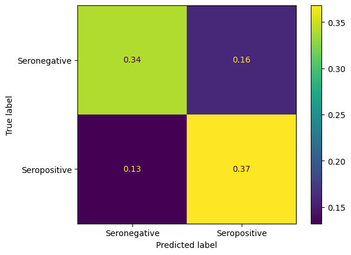

```python
results_dict['XGBoost-Boruta'] = print_results(xbm_boruta, y_test, xbm_boruta.predict(X_test_boruta), xbm_boruta.predict_proba(X_test_boruta)[:, 1])
```

```python
shap_20_feature_set = set(best_20_shap.index)
boruta_feature_set = set(X.columns[bfs.ranking_ == 1].values)
intersection = shap_20_feature_set.intersection(boruta_feature_set)

X_train_intersection = X_train[list(intersection)]
X_test_intersection = X_test[list(intersection)]

base_est = xgboost.XGBClassifier(tree_method='hist', importance_type='total_gain')
param_grid={'max_depth': [2, 3, 4], 'n_estimators': list(range(20, 41, 5)), 'reg_lambda': np.linspace(0, 500, 6)}
gscv_intersection = GridSearchCV(base_est, param_grid=param_grid, n_jobs=-1)
gscv_intersection.fit(X_train_intersection, y_train)
xbm_intersection, xbm_params_intersection = gscv_intersection.best_estimator_, gscv_intersection.best_params_
y_pred = xbm_intersection.predict_proba(X_test_intersection)[:, 1]
xbm_score_test_intersection = roc_auc_score(y_test, y_pred)

print(f'AUC score for max_depth={xbm_params_intersection["max_depth"]}, n_estimators={xbm_params_intersection["n_estimators"]}, reg_lambda={xbm_params_intersection["reg_lambda"]:.2f}: {xbm_score_test_intersection:.4f} (test)')
```

```
AUC score for max_depth=3, n_estimators=40, reg_lambda=100.00: 0.7741 (test)
```

```
Accuracy: 0.6943
ROC-AUC: 0.7741
F1-score: 0.7024
F-beta score 0.6915750915750916
```

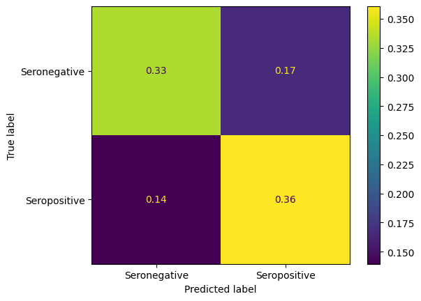

```python
results_dict['XGBoost-Intersection'] = print_results(xbm_intersection, y_test, xbm_intersection.predict(X_test_intersection), xbm_intersection.predict_proba(X_test_intersection)[:, 1])
```

```python
pd.DataFrame(results_dict).T.sort_values(by='auc', ascending=False)
```

|  | acc | auc | f1 | f_beta |
| --- | --- | --- | --- | --- |
| XGBoost | 0.705006 | 0.781293 | 0.714497 | 0.701118 |
| XGBoost-SHAP | 0.702331 | 0.780380 | 0.710301 | 0.699224 |
| XGBoost-Boruta | 0.708063 | 0.780037 | 0.715985 | 0.704669 |
| XGBoost-Intersection | 0.694306 | 0.774087 | 0.702381 | 0.691575 |
| KNN | 0.690103 | 0.753267 | 0.680331 | 0.693618 |
| Logistic Regression | 0.682843 | 0.745708 | 0.672196 | 0.686180 |

# Deep Learning

### Why

- **Goal:** Improve **ROC AUC** by capturing complex ECG patterns.
- **Model Choices:** **CNNs & RNNs** handle **spatial & temporal dependencies** better than FNNs.
- **Hybrid Approach:** **1D CNNs** extract features, **RNNs** model time dependencies (**SOTA** for ECG tasks).
- **Better Performance:** Despite complexity, deep learning can **outperform traditional ML**.

### Explainability

- **Deep Learning = Black Box?** Yes, but **SHAP, and Grad-CAM** help interpret predictions.
- **SHAP Values:** Show **feature importance** in model decisions.
- **Grad-CAM:** Highlights **important ECG leads**, testing if **lead II** is most relevant.
- **Approach:** Use **Grad-CAM** for deeper insights.

```python
X_train, X_test, y_train, y_test = train_test_split(X, y, test_size=0.2, random_state=SEED, stratify=y)

X_train, X_val, y_train, y_val = train_test_split(X_train, y_train, test_size=0.10, random_state=SEED, stratify=y_train)

print("Train", len(X_train))
print("Val", len(X_val))
print("Test", len(X_test))
```

```
Train 9425
Val 1048
Test 2619
```

```python
BATCH_SIZE = 32

train_dataset = ECGDataset(X_train, y_train)
val_dataset = ECGDataset(X_val, y_val)
test_dataset = ECGDataset(X_test, y_test)
train_dloader = DataLoader(train_dataset, batch_size=BATCH_SIZE, shuffle=True, pin_memory=True)
val_dloader = DataLoader(val_dataset, batch_size=BATCH_SIZE, shuffle=False, pin_memory=True)
test_dloader = DataLoader(test_dataset, batch_size=BATCH_SIZE, shuffle=False)
```

### Model

- **1D Conv SE-ResNet18**: A **ResNet18-based CNN** with **squeeze-and-excitation blocks** to capture spatial dependencies across ECG leads.
- **Demographic Integration**: A **Fully Connected Network (FCN)** processes demographic data, concatenated with CNN outputs before the final prediction.
- **Advanced Methods** (for future work): **Attention mechanisms** or **FiLM layers** could **modulate CNN features** based on demographics for better adaptation.
- **Why Concatenation?** Simpler and sufficient for our current dataset, but future scaling may benefit from more complex approaches.

```python
device = torch.device("cuda" if torch.cuda.is_available() else "cpu")

# Initialize model
resnet = ResNet(BasicBlock, **resnet_params)
resnet.to(device)

# Positive class weight
pos_weight = (y==0.).sum()/y.sum()

# Define loss function, optimizer, and scheduler
criterion = nn.BCEWithLogitsLoss(pos_weight=torch.tensor(pos_weight))
optimizer = torch.optim.AdamW(resnet.parameters(), lr=1e-3, weight_decay=1e-4)
scheduler = torch.optim.lr_scheduler.CosineAnnealingLR(optimizer, eta_min=1e-5, T_max=74*15)

# Define epochs and patience
epochs = 30
patience = 10
```

```
Accuracy: 0.7511
ROC-AUC: 0.8439
F1-score: 0.7574
F-beta score 0.7461155086484902
```

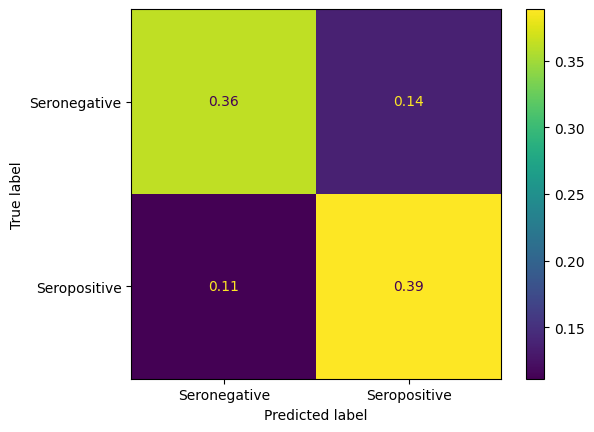

```python
results_dict['SE-ResNet18'] = print_results(resnet, y_test, y_pred_resnet, y_pred_proba_resnet)
```

## Grad-CAM

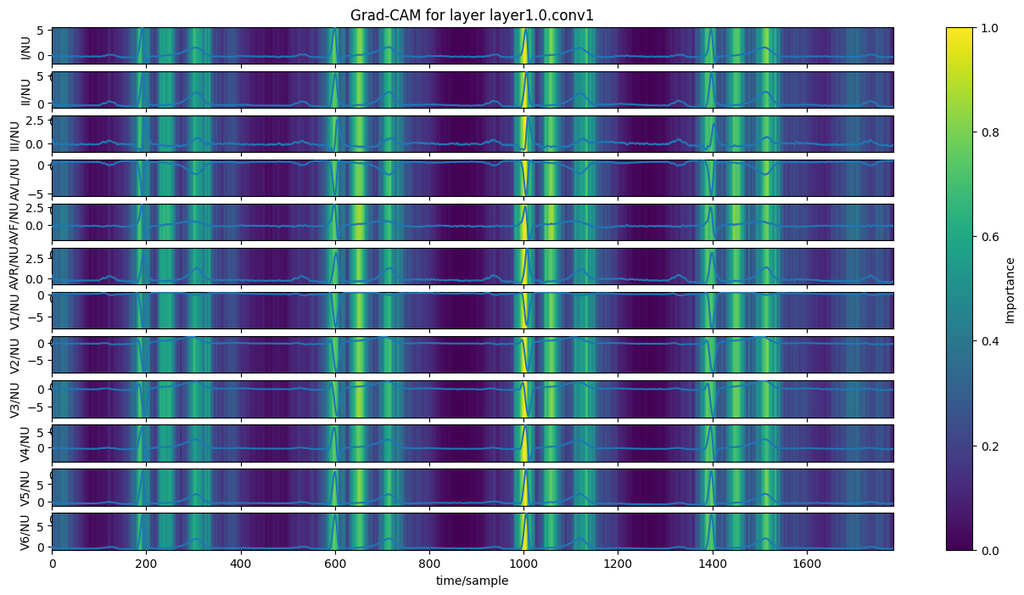

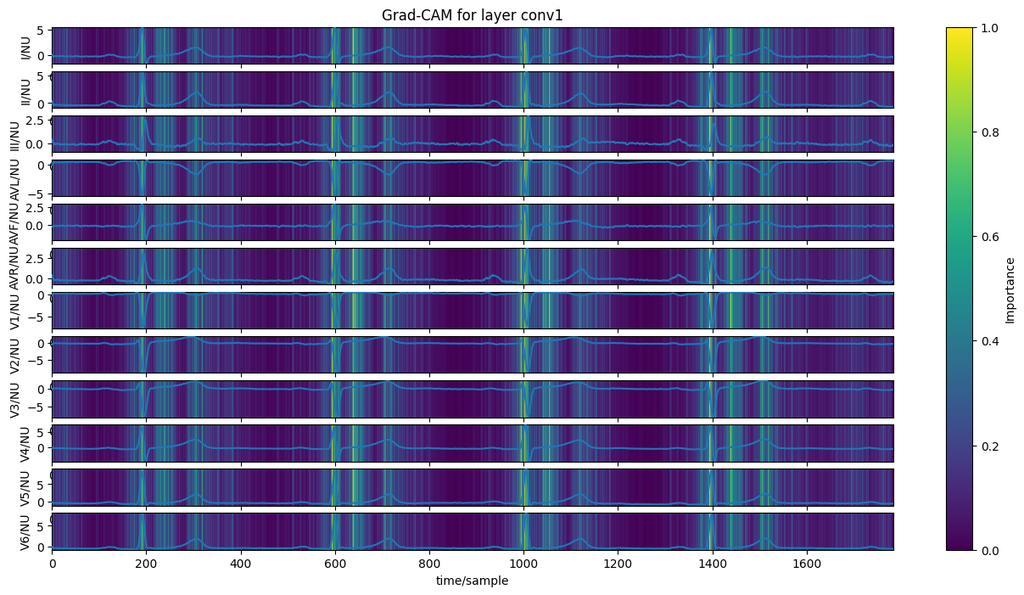

```python
example = next(iter(gradcam_loader))
signal = example[0].squeeze(0).transpose(0, 1).cpu().numpy()
leads = ['I', 'II', 'III', 'AVL', 'AVF', 'AVR', 'V1', 'V2', 'V3', 'V4', 'V5', 'V6']
layers = ['layer1.0.conv1', 'conv1']
for layer in layers:
    heatmap = get_grad_cam(net=model, test_example=example, target_layer=layer)
    visualize_signal(signal, heatmap, leads, sampling_freq=400, title=f"Grad-CAM for layer {layer}")
```

# Transformers

## Model Architecture

### Why using a Transformer

- **Captures Complex ECG Relationships**: Utilizes **self-attention** to model both local and long-range dependencies in ECG data.
- **Proven Success in Various Domains**: A robust and scalable framework for developing accurate diagnostic models.

**Starting Point:** Annamalai Natarajan et al. [[6]](https://www.cinc.org/archives/2020/pdf/CinC2020-107.pdf):

- used a transformer model to detect cardiac abnormalities from 12-lead ECG recordings.
- demonstrated success winning the first place in the [2020 PhysioNet challenge](https://moody-challenge.physionet.org/2020/results/)

### Feature extraction

- Inspired by Annamalai Natarajan et al [[6]](https://www.cinc.org/archives/2020/pdf/CinC2020-107.pdf) ,
- **Sequential Encoder Architecture**:
  - Composed of **multiple 1D convolutional layers** for feature extraction.
  - Designed to **capture local temporal patterns** using filters with varied kernel sizes and strides.
  - **Batch normalization** & **ReLU** activations ensure **stable training and non-linearity** [[6]](https://www.cinc.org/archives/2020/pdf/CinC2020-107.pdf).
  - Downsamples ECG signals by a factor of 20, **reducing computational complexity**.

### Positional Encoding

**Problem:**

- The ECG capture the temporal dynamics of the heart's electrical activity
- The transformer does not inherently consider sequence order.

**Solution: Positional Encoding**

- Adds order and relative position information to the model.
- Helps capture temporal dynamics in ECG signals.
- Enables the model to recognize sequential patterns in heart activity.

```python
#Parameters
model_parameters = {
    "d_model": 256,
    "nhead" :8,
    "d_ff" : 2048,
    "num_layers" : 8,
    "dropout_rate" : 0.2,
    "deepfeat_sz" : 64
}

learning_rate = 1e-4
weight_decay = 1e-3
```

```python
device = torch.device("cuda" if torch.cuda.is_available() else "cpu")

ctn = CTN(**model_parameters)
ctn.to(device)

# Positive class weight
pos_weight = (y==0.).sum()/y.sum()

# Define loss function, optimizer, and scheduler
criterion = nn.BCEWithLogitsLoss(pos_weight=torch.tensor(pos_weight))
optimizer = torch.optim.AdamW(ctn.parameters(), lr=learning_rate, weight_decay=weight_decay)
scheduler = torch.optim.lr_scheduler.CosineAnnealingLR(optimizer, eta_min=1e-6, T_max=295*15)
```

```
Accuracy: 0.7331
ROC-AUC: 0.8234
F1-score: 0.7127
F-beta score 0.7471561530506722
```

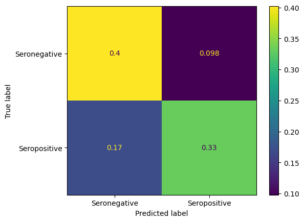

```python
y_pred_ctn, y_pred_proba_ctn = evaluate_model(ctn, test_dloader, device, with_demographic=False, with_handcrafted=False)
results_dict['CTN'] = print_results(ctn, y_test, y_pred_ctn, y_pred_proba_ctn)
```

## Transformer model with age and sex

**Problem:**

- The **ECG dosn't give information about Age and Sex** of a patient
  - **Age:** Cardiac abnormalities develop over time
  - **Sex**: Differences in heart rate variability and ECG patterns enhance classification.

**Solution:**

- Augment the transformer's output with demographic (age & sex) features
- Demographic vector is concatenated with the feature representation

We define the training procedure as before

```
Accuracy: 0.7316
ROC-AUC: 0.8277
F1-score: 0.7590
F-beta score 0.7153011113982941
```

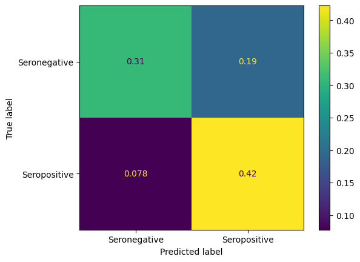

```python
y_pred_ctn_demographic, y_pred_proba_ctn_demographic = evaluate_model(ctn_demographic, test_dloader, device, with_demographic=True, with_handcrafted=False)
results_dict['Demog-Transformer'] = print_results(ctn_demographic, y_test, y_pred_ctn_demographic, y_pred_proba_ctn_demographic)
```

## Transformer with top 20 handfeatures (SHAP)

**Idea:**

- Enriches the model’s representation by integrating domain-specific insights that capture subtle signal characteristics.
- Followed the approach from [[6]](https://www.cinc.org/archives/2020/pdf/CinC2020-107.pdf)

**Feature Augmentation**

- Integrate ECG features extracted during preprocessing.
- Combined ECG-derived features with transformer-encoded representations.
- Used SHAP (SHapley Additive exPlanations) instead of Random Forest feature importance.

```
Accuracy: 0.7461
ROC-AUC: 0.8379
F1-score: 0.7536
F-beta score 0.7406058840664143
```

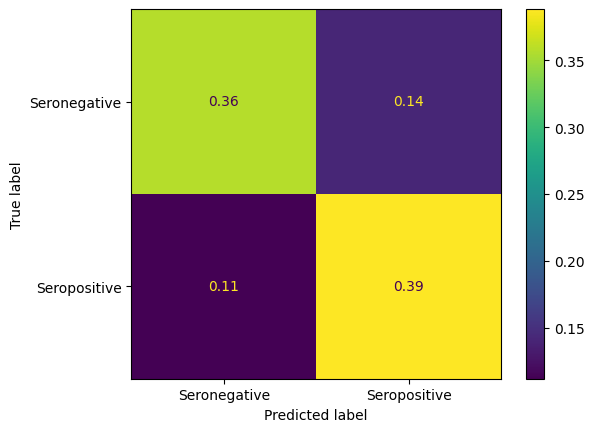

```python
y_pred_handcrafted, y_pred_proba_handcrafted = evaluate_model(ctn_handcrafted, test_dloader, device, with_demographic=True, with_handcrafted=True)
results_dict['Handcrafted-Transformer'] = print_results(ctn_handcrafted, y_test, y_pred_handcrafted, y_pred_proba_handcrafted)
```

# ROC Curves

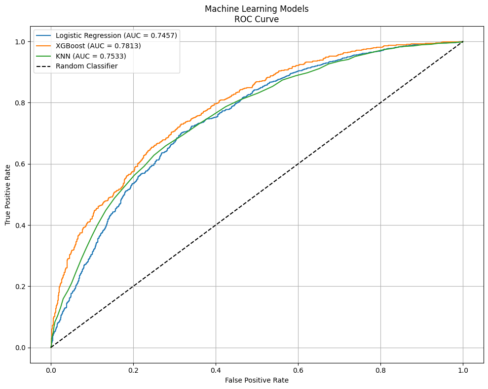

```python
fig
```

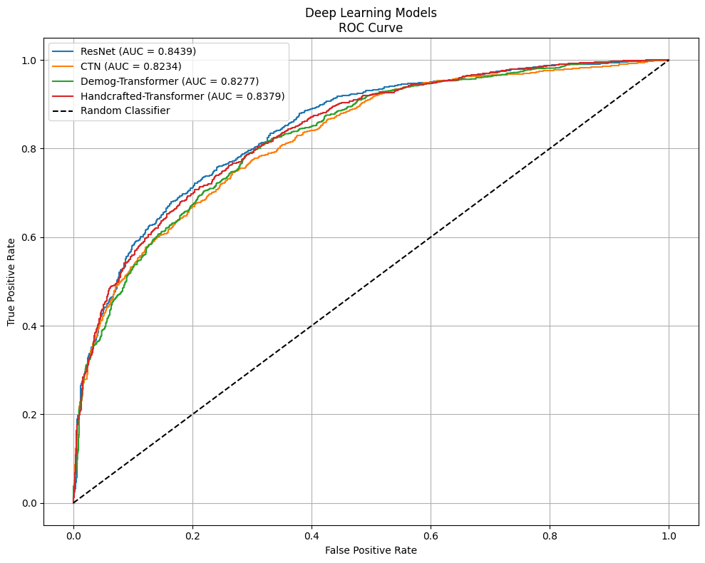

```python
fig
```

# Model Comparison

```python
pd.DataFrame(results_dict).T.sort_values(by='auc', ascending=False)
```

|  | acc | auc | f1 | f_beta |
| --- | --- | --- | --- | --- |
| SE-ResNet18 | 0.751050 | 0.843945 | 0.757440 | 0.746116 |
| Handcrafted-Transformer | 0.746086 | 0.837884 | 0.753612 | 0.740606 |
| Demog-Transformer | 0.731577 | 0.827712 | 0.758999 | 0.715301 |
| CTN | 0.733104 | 0.823354 | 0.712700 | 0.747156 |
| XGBoost | 0.705006 | 0.781293 | 0.714497 | 0.701118 |
| KNN | 0.690103 | 0.753267 | 0.680331 | 0.693618 |
| Logistic Regression | 0.682843 | 0.745708 | 0.672196 | 0.686180 |

# References

- [1] ["Detection of Chagas Disease from the ECG: The George B. Moody PhysioNet Challenge 2025 "](https://moody-challenge.physionet.org/2025/)
- [2] ["CODE-15%: a large scale annotated dataset of 12-lead ECGs "](https://zenodo.org/records/4916206)
- [3], "Relationship of electrocardiographic abnormalities and seropositivity to Trypanosoma cruzi within a rural community in northeast Brazil", J H Maguire et al.90529-x)
- [4] ["Electrocardiographic Characteristics in a Population with High Rates of Seropositivity for Trypanosoma cruzi Infection", 09/2007 , S. Williams-Blangero et al.](https://doi.org/10.4269/ajtmh.2007.77.495)
- [5] ["The PR Interval & PR segment"](https://ecgwaves.com/topic/the-pr-interval-pr-segment/)
- [6] ["A Wide and Deep Transformer Neural Network for 12-Lead ECG Classification", Annamalai Natarajan et al.](https://www.cinc.org/archives/2020/pdf/CinC2020-107.pdf)
- [7] ["Clinical features of Chagas disease progression and severity"](https://doi.org/10.1016/j.lana.2024.100832)